# Proteomics assignment

Mikhail Ushakov

2024-04-20

# Load data

```r
data <- read.csv('peaks_data.csv')
```

# EDA & Preprocessing

## Filtration

Remove genes with half and more missing values

```r
rows_with_NA <- which(rowSums(is.na(data)) > ncol(data)/2)
data_filt <- data[!rownames(data) %in% rows_with_NA, ]
```

Filter duplicated genes

```r
duplicated_genes <- data_filt %>% group_by(Gene_id) %>%  count() %>% filter(n > 1) %>% pull(Gene_id)
data_filt <- data_filt %>% filter(!Gene_id %in% duplicated_genes)
rownames(data_filt) <- data_filt$Gene_id
```

## NA values imputation

```r
data_t <- data_filt %>% dplyr::select(where(is.numeric)) %>% t() %>%  as.matrix()
data_knn <- impute.knn(data_t, k = 5)
data_knn <- data_knn$data
data_knn <- as.data.frame(data_knn)
#knn_yeast$LEU2 <- knn_yeast$LEU2 / 2
#knn_yeast$URA3 <- knn_yeast$URA3 / 2
data_knn <- t(as.matrix(data_knn))
```

```r
experiment <- as.factor(gsub('_[0-9]+', '', colnames(data_knn)))
```

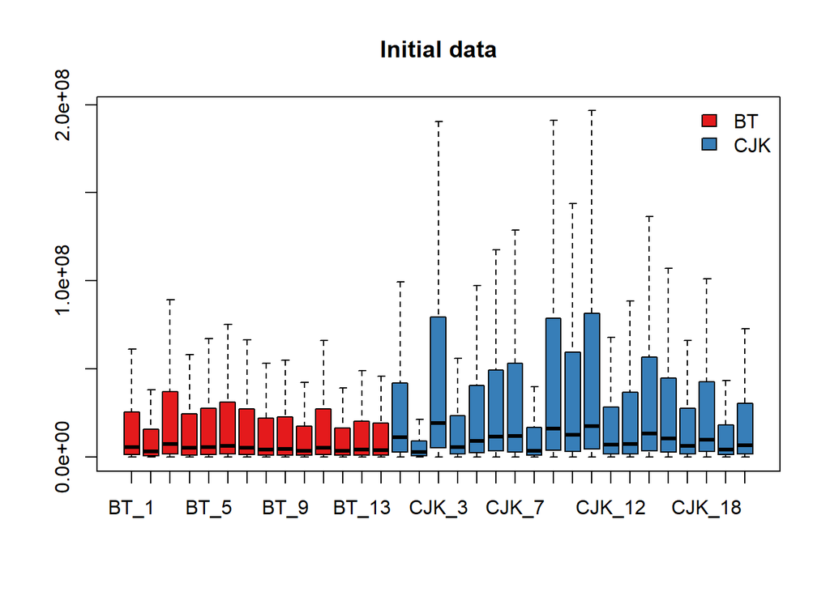

```r
pal <- brewer.pal(n = 9, name = "Set1")
cols <- pal[experiment]
boxplot(data_knn, outline = FALSE, main = "Initial data", col = cols)
legend("topright", levels(experiment), fill = pal, bty = "n", xpd = T)
```

## Normalization

Perform log- and quantile normalization

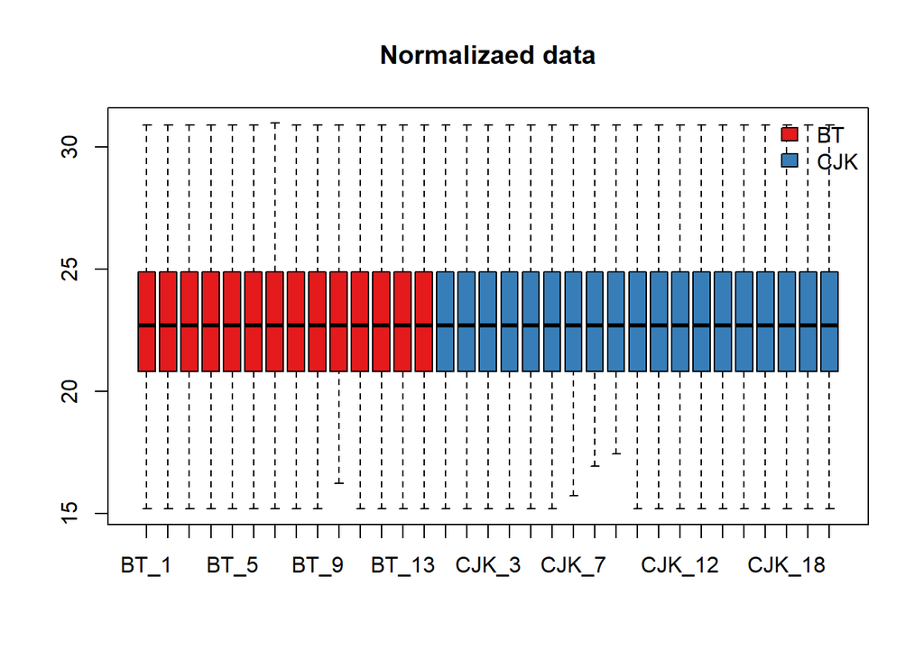

```r
data_log <- log2(data_knn + 1)
data_norm <- normalizeQuantiles(as.matrix(data_log))
boxplot(data_norm, outline = FALSE, main = "Normalizaed data", col = cols)
legend("topright", levels(experiment), fill = pal, bty = "n", xpd = T)
```

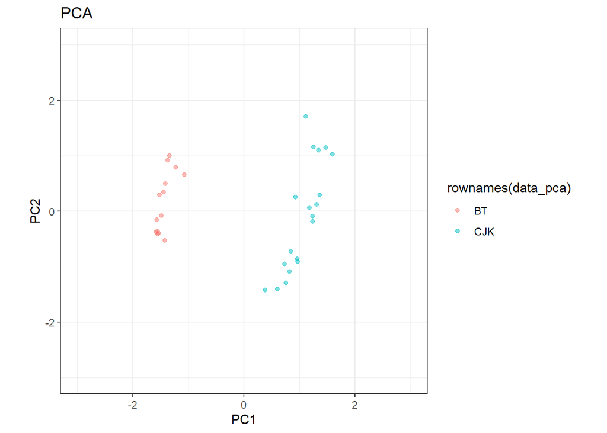

```r
data_pca <- t(data_norm)
terapod_pca <- rda(data_pca, scale = TRUE)

rownames(data_pca) <- experiment

df_scores <- data.frame(data_pca,
                        scores(terapod_pca, display = "sites", choices = c(1, 2, 3), scaling = "sites"))

p_scores <- ggplot(df_scores, aes(x = PC1, y = PC2)) +
  geom_point(aes(color = rownames(data_pca)), alpha = 0.5) +
  coord_equal(xlim = c(-3, 3), ylim = c(-3, 3)) + ggtitle(label = "PCA") + theme_bw()
p_scores
```

Groups are well discriminated by PC1

## MA-plot

```r
maplot <- function(X1, X2, pch = 21, main = "MA-plot", xlab = "Average log-expression", ylab = "Expression log-ratio", lpars = list(col = "blue", lwd = 2), ...){
  # Координаты
  X <- (rowMeans(X2) + rowMeans(X1)) / 2
  Y <- rowMeans(X2) - rowMeans(X1)
  # График
  scatter.smooth(x = X, y = Y, main = main, pch = pch, xlab = xlab, ylab = ylab, lpars = lpars, ...)
  abline(h = c(-1, 0, 1), lty = c(2, 1, 2))
}
```

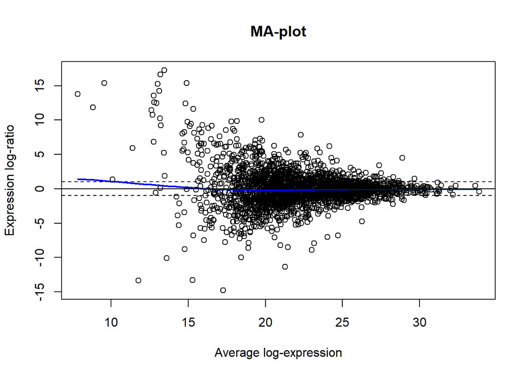

```r
maplot(data_norm[, 1:14], data_norm[, 15:33])
```

# DE

## Prepare dataset

```r
expr_data <- as.matrix(data_norm)

# Sample data
pheno_data <- data.frame(experiment)
rownames(pheno_data) <- colnames(data_norm)
pheno_metadata <- data.frame(
  labelDescription = c("Experimental condition"),
  row.names=c("Condition"))
pheno_data <- new("AnnotatedDataFrame",
                 data = pheno_data,
                 varMetadata = pheno_metadata)

# Traits data
feature_data <- data.frame(Prot = rownames(expr_data))
rownames(feature_data) <- rownames(expr_data)
feature_metadata <- data.frame(
  labelDescription = c("Protain name"),
  row.names = c("Protain"))
f_data <- new("AnnotatedDataFrame",
              data = feature_data,
              varMetadata = feature_metadata)

# Combine
exp_set <-
  ExpressionSet(assayData = expr_data,
                phenoData = pheno_data,
                featureData = f_data)
```

## limma

```r
X <- model.matrix(~ experiment, pData(exp_set))
fit <- lmFit(exp_set, design = X, method = "robust", maxit = 1000)
efit <- eBayes(fit)
```

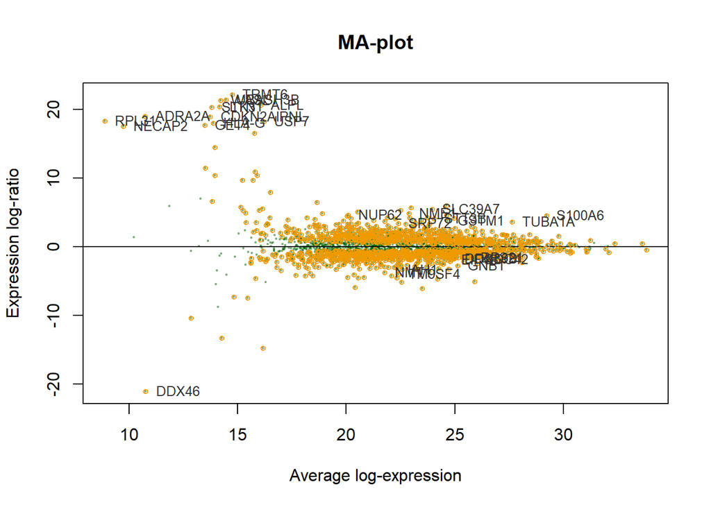

```r
MA_limma <- function(efit, coef, n = 10, signif = TRUE, fdr = 0.05, lfc = 0, text = TRUE, cex.text = 0.8, col.text = "grey20", main = "MA-plot", xlab = "Average log-expression", ylab = "Expression log-ratio", pch = 19, pch.signif = 21, col = "darkgreen", alpha = 0.3, cex = 0.3, ...){
  # соотношение и интенсивность
  R <- efit$coefficients[, coef]
  I <- efit$Amean
  # прозрачный цвет
  col_btransp <- adjustcolor(col, alpha.f = alpha)
  # график
  plot(I, R, cex = cex, main = main, pch = pch, xlab = xlab, ylab = ylab, col = col_btransp, ...)
  abline(h = 0)
  # отмечаем дифференциально-экспрессируемые белки
  if(signif){
    sign <- p.adjust(efit$p.value[, coef], method = "BH") <= fdr
    large <- abs(efit$coefficients[, coef]) >= lfc
    points(I[sign & large], R[sign & large], cex = cex*2, col = "orange2", pch = pch.signif)
  }
  # подписываем первые n белков с сильнее всего различающейся экспрессией
  if(text){
    ord <- order(efit$lods[, coef], decreasing = TRUE)
    top_n <- ord[1:n]
    text(I[top_n], R[top_n], labels = efit$genes[top_n, ], pos = 4, cex = cex.text, col = col.text)
  }
}


MA_limma(efit, coef = 2, n = 30)
```

## DE proteins exploration

### Top proteins

```r
my_list <- topTable(efit, coef = 2, n = 100)
dif_exp_set <- exp_set[fData(exp_set)$Prot %in% my_list$Prot, ]
my_list
```

```
##                        Prot       logFC   AveExpr          t      P.Value
## DDX46                 DDX46 -21.1001041 10.764021 -163.24075 1.172756e-49
## LTN1                   LTN1  20.3619944 14.170585  124.67510 8.599365e-46
## TRMT6                 TRMT6  22.1292214 14.754740  111.08139 3.881206e-44
## RPL31                 RPL31  18.2809079  8.878385  111.24955 3.692272e-44
## STK3                   STK3  20.3126342 13.794904  100.28187 1.132153e-42
## UBASH3B             UBASH3B  21.3821208 14.465411   70.67122 1.141695e-37
## ADRA2A               ADRA2A  19.0242770 10.743453   38.09427 6.656196e-29
## WASL                   WASL  21.2900726 14.213371   37.04519 1.642224e-28
## NECAP2               NECAP2  17.5438854  9.728092   32.71242 9.034540e-27
## CDKN2AIPNL       CDKN2AIPNL  18.9155113 13.737491   32.67543 9.368777e-27
## NME1                   NME1   4.8782604 22.890286   26.69055 5.943142e-24
## TM9SF4               TM9SF4  -4.0090825 22.391910  -25.61379 2.182722e-23
## GSTM1                 GSTM1   3.7618281 24.662368   25.02782 4.524672e-23
## GET4                   GET4  17.6927075 13.488695   22.48045 1.300727e-21
## ALPL                   ALPL  20.6136814 16.064141   20.56931 2.030233e-20
## NMT1                   NMT1  -3.7859971 21.770456  -20.40622 2.592861e-20
## IAH1                   IAH1  -3.3732127 22.366097  -18.83417 2.996392e-19
## CDC42                 CDC42  -1.8154826 25.862577  -17.84831 1.519302e-18
## HLA-G                 HLA-G  18.0373527 13.881959   17.73974 1.824874e-18
## SLC39A7             SLC39A7   5.4993754 23.948511   17.18733 4.703703e-18
## NUP62                 NUP62   4.6360690 20.091661   17.15680 4.959875e-18
## SRP72                 SRP72   3.3926014 22.403049   16.84035 8.633844e-18
## EIF4B                 EIF4B  -1.9399491 24.828067  -16.49506 1.595962e-17
## USP7                   USP7  18.2114082 16.204528   16.15596 2.947034e-17
## DDX39B               DDX39B  -1.7847302 24.966145  -15.99315 3.970378e-17
## RPS21                 RPS21  -1.5798537 25.697934  -15.92804 4.476009e-17
## GNB1                   GNB1  -2.7467398 25.126338  -15.82696 5.395477e-17
## STT3B                 STT3B   4.0735943 24.031396   15.78865 5.792838e-17
## TUBA1A               TUBA1A   3.6164939 27.635792   15.66527 7.288920e-17
## S100A6               S100A6   4.5483035 29.213633   15.52515 9.477885e-17
## SCYL2                 SCYL2   4.0941642 22.263048   15.23293 1.648606e-16
## RND3                   RND3  -1.7705184 24.359038  -15.17966 1.825264e-16
## POTEI                 POTEI  -5.1419004 22.550438  -14.73235 4.336868e-16
## IDH3B                 IDH3B   4.1288007 24.955026   14.63581 5.240914e-16
## SRSF6                 SRSF6   4.4904737 20.048095   14.56569 6.017188e-16
## DHRS7B               DHRS7B  -1.2083031 25.504503  -14.38066 8.683560e-16
## TMOD3                 TMOD3  -1.6371736 24.859026  -14.28862 1.043533e-15
## YWHAQ                 YWHAQ  -1.6198482 26.981577  -14.01577 1.808429e-15
## SEPTIN6             SEPTIN6  -1.3918839 26.194065  -13.96078 2.022265e-15
```

[output cut: 147 more lines]

```
## TOMM40        5.084769e-11 18.28087
## PSMA7         5.154743e-11 18.25726
## XPO1          5.186599e-11 18.25009
## EIF4H         5.418899e-11 18.17692
## SLC1A5        5.418899e-11 18.16263
## AP2A2         5.801681e-11 18.10087
## PPP1R12A      5.852540e-11 18.06212
## PRKAR2A       5.825950e-11 18.05870
## NAA10         6.336604e-11 18.03334
## SDF4          6.384173e-11 17.95376
## SF3B1         6.643845e-11 17.90898
## ALDH9A1       6.767581e-11 17.87192
## YWHAH         6.948248e-11 17.82789
## DDRGK1        7.411909e-11 17.80226
## ACTBL2        7.360169e-11 17.76593
```

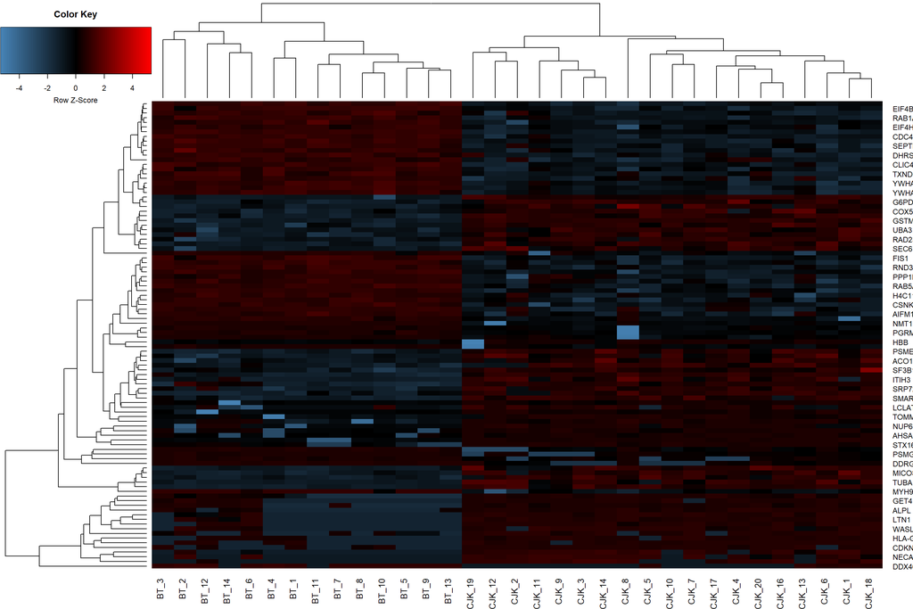

```r
dat <- as.matrix(exprs(dif_exp_set))
# после дополнительной стандартизации по белкам
pal_blue_red <- colorpanel(75, low = "steelblue", mid = "black", high = "red")
heatmap.2(dat, col = pal_blue_red, scale = "row", key = TRUE, symkey = FALSE, density.info = "none", trace = "none", cexRow = 0.9, cexCol = 1, margins = c(4, 3), keysize = 0.8, key.par = list(mar = c(3, 0.1, 3, 0.1)))
```

See several clusters overexpressed in one of groups

```r
topTable(efit, coef = 2)
```

```
##                  Prot     logFC   AveExpr          t      P.Value    adj.P.Val
## DDX46           DDX46 -21.10010 10.764021 -163.24075 1.172756e-49 2.849797e-46
## LTN1             LTN1  20.36199 14.170585  124.67510 8.599365e-46 1.044823e-42
## TRMT6           TRMT6  22.12922 14.754740  111.08139 3.881206e-44 2.357833e-41
## RPL31           RPL31  18.28091  8.878385  111.24955 3.692272e-44 2.357833e-41
## STK3             STK3  20.31263 13.794904  100.28187 1.132153e-42 5.502263e-40
## UBASH3B       UBASH3B  21.38212 14.465411   70.67122 1.141695e-37 4.623865e-35
## ADRA2A         ADRA2A  19.02428 10.743453   38.09427 6.656196e-29 2.310651e-26
## WASL             WASL  21.29007 14.213371   37.04519 1.642224e-28 4.988256e-26
## NECAP2         NECAP2  17.54389  9.728092   32.71242 9.034540e-27 2.276613e-24
## CDKN2AIPNL CDKN2AIPNL  18.91551 13.737491   32.67543 9.368777e-27 2.276613e-24
##                   B
## DDX46      80.76805
## LTN1       78.82193
## TRMT6      78.38445
## RPL31      76.93038
## STK3       76.87707
## UBASH3B    70.45060
## ADRA2A     54.97536
## WASL       54.00223
## NECAP2     50.45426
## CDKN2AIPNL 50.35014
```

```r
numGenes <- nrow(exprs(exp_set))
full_list <- topTable(efit, number = numGenes)
full_list <- full_list[full_list$adj.P.Val <= 0.05,]
nrow(full_list)
```

```
## [1] 1447
```

### Volcano plot

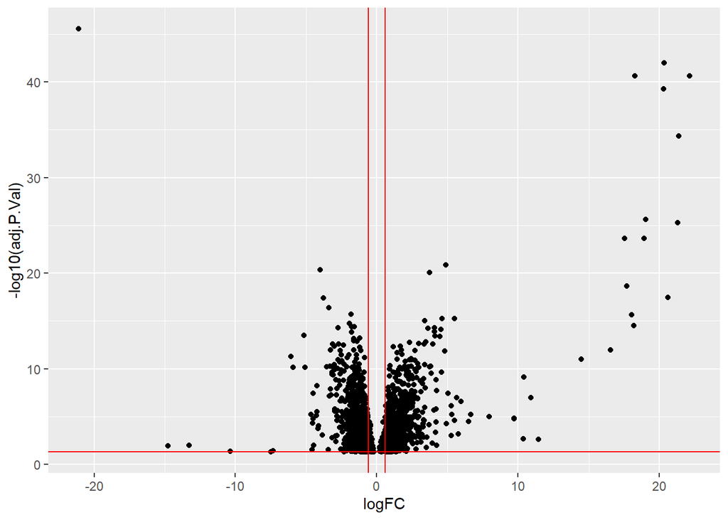

```r
volcano_list <- full_list

volcano1 <- ggplot(data = volcano_list, aes(x = logFC, y = -log10(adj.P.Val))) + geom_point()

volcano2 <- volcano1 + geom_vline(xintercept=c(-0.6, 0.6), col="red") +
  geom_hline(yintercept=-log10(0.05), col="red")

volcano2
```

```r
volcano_list$diffexpressed[volcano_list$logFC > 1 & volcano_list$adj.P.Val < 0.05] <- "UP"
```

if log2Foldchange < -1 and pvalue < 0.05, set as “DOWN” (можно -0.06)

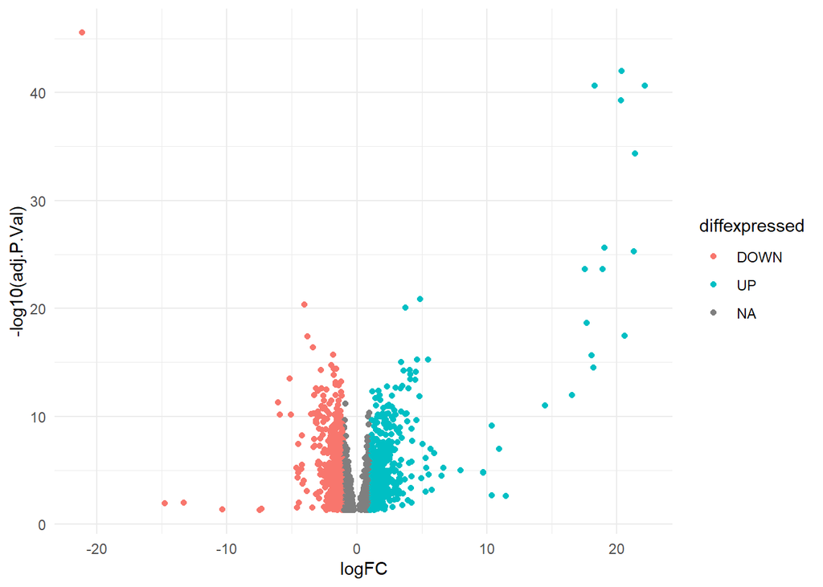

```r
volcano_list$diffexpressed[volcano_list$logFC < -1 & volcano_list$adj.P.Val< 0.05] <- "DOWN"

volcanodif1 <- ggplot(data = volcano_list, aes(x = logFC, y = -log10(adj.P.Val), col = diffexpressed)) + geom_point() + theme_minimal()
volcanodif1
```

### Ordination by DE proteins

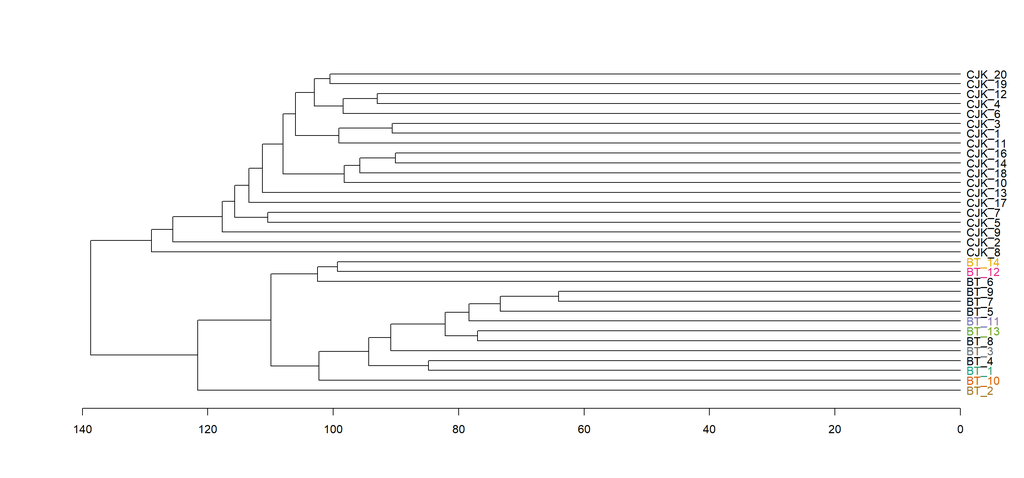

```r
diff_prot <- rownames(full_list)
diff_expressed <- as.data.frame(data_norm)[diff_prot,]
t_diff_expressed <- t(diff_expressed)
#rownames(t_diff_expressed) <-  as.factor(gsub("_[^_]*", replacement = "", rownames(t_diff_expressed)))
#rownames(t_diff_expressed) <- make.unique(as.character(pheno$yeast_experiment))

d <- dist(x = t_diff_expressed, method = "canberra")

mouse_hc_avg <- hclust(d, method = "average")
mouse_ph_avg <- as.phylo(mouse_hc_avg)
mouse_den_avg <- as.dendrogram(mouse_hc_avg)

get_colours <- function(dend, n_chars, palette = "Dark2"){ #nchars = первые нескольок симовлов которые будут использоваться для разделения фактора на группы
labs <- get_leaves_attr(dend, "label")
group <- substr(labs, start = 0, stop = n_chars)
group <- factor(group)
cols <- brewer.pal(length(levels(group)), name = palette)[group]
return(cols)
}

cols <- get_colours(dend = mouse_den_avg, n_chars = 6)
den_avg_c <- color_labels(dend = mouse_den_avg, col = cols)
plot(den_avg_c, horiz = TRUE)
```

# GO enrichment

Filter bad names

```r
library(clusterProfiler)
library(org.Hs.eg.db)
```

```r
full_list <- full_list %>% filter(!grepl("\n", Prot))
```

```r
up_df <- subset(full_list, logFC > 0)
# get the significant down-regulated proteins
down_df <- subset(full_list, logFC < 0)
```

```r
up_gene.df <- bitr(
  up_df$Prot, fromType = "SYMBOL",
  toType = c("ENSEMBL","ENTREZID"),
  OrgDb = org.Hs.eg.db)
```

```r
down_gene.df <- bitr(
  down_df$Prot, fromType = "SYMBOL",
  toType = c("ENSEMBL","ENTREZID"),
  OrgDb = org.Hs.eg.db)
```

```r
ego_up <- enrichGO(gene = up_gene.df$ENTREZID[!is.na(up_gene.df$ENTREZID)],
                     OrgDb = "org.Hs.eg.db",
                     keyType = "ENTREZID",
                     ont = "BP",
                     pAdjustMethod = "BH",
                     pvalueCutoff = 0.02,
                     qvalueCutoff = 0.05)
```

```r
ego_down <- enrichGO(gene = down_gene.df$ENTREZID[!is.na(down_gene.df$ENTREZID)],
                     OrgDb = "org.Hs.eg.db",
                     keyType = "ENTREZID",
                     ont = "BP",
                     pAdjustMethod = "BH",
                     pvalueCutoff = 0.02,
                     qvalueCutoff = 0.05)
```

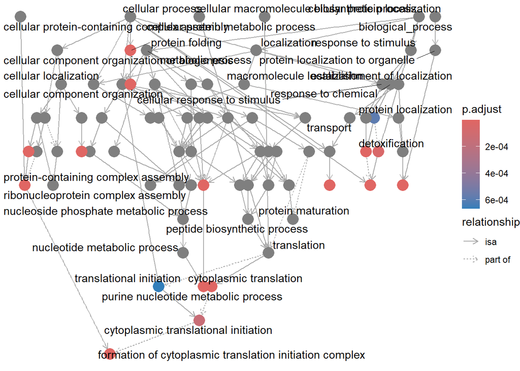

```r
goplot(ego_up)
```

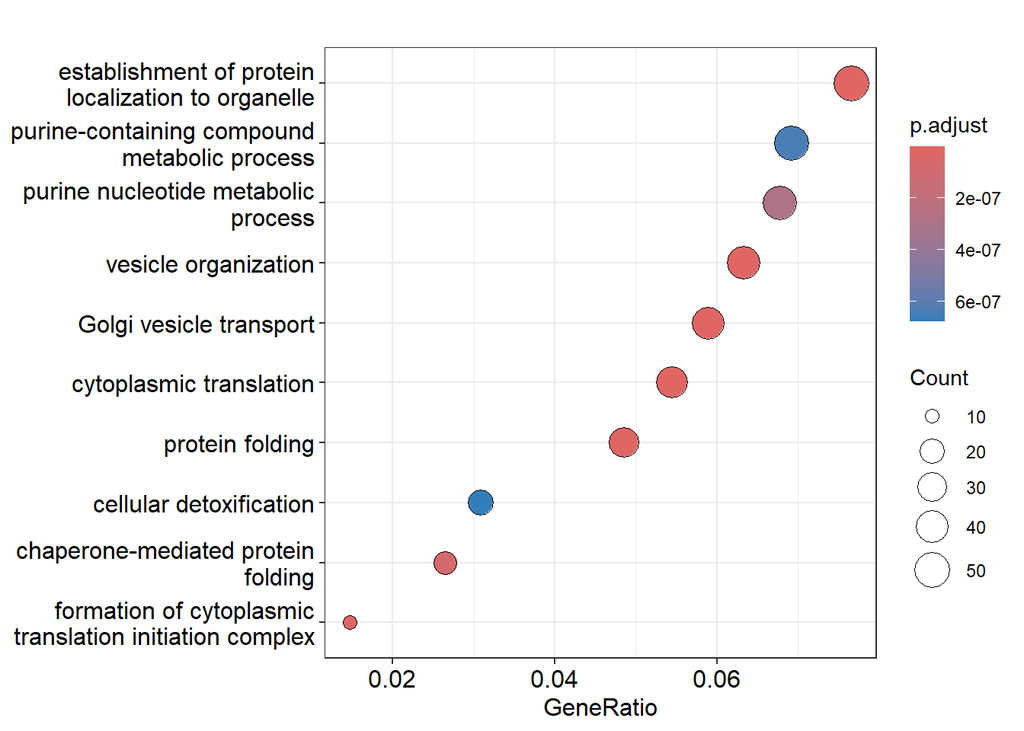

```r
dotplot(ego_up)
```

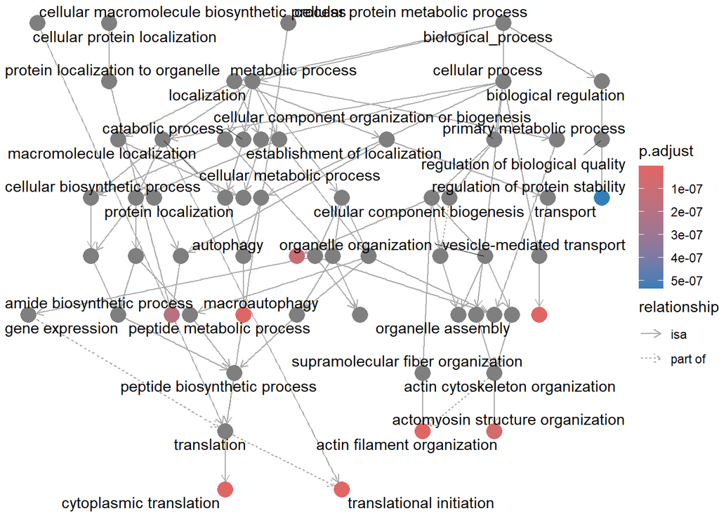

```r
goplot(ego_down)
```

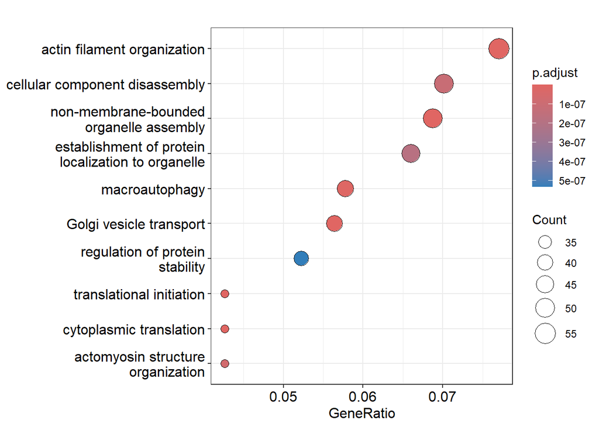

```r
dotplot(ego_down)
```

# Conclusions

Upregulation of processes related to protein localization suggests changes in localization of proteins potentially indicating changes in organelle function or cellular compartmentalization in response to heart valve calcification. Purines are essential for ATP and GTP production and upregulation of purine dependent metabolic processes may reflect increase demand for purine nucleotides, possibly due to higher cellular activity or some stress response. Also there are some transport and organelle organisation upregulated processes. It may be a sign of ongoing cellular remodeling, repair processes etc. Protein folding processes also indicate some increased cellular activity. The most interesting process here is cellular detoxification, which is probably related to heart valve calcification.

Among the down-regulated processes we can see similar terms related to protein metabolism, organelle dynamics and cellular maintenance. Disruption of actin filament organization can imacp cellular morphology, mechanical proteprites and contractile function in tissues. Downregularion of macroauthophagy indicates reduced cellular recycling ability. Also it seems there are some problems with translation and overall protein metabolism.